1

Vol.:(0123456789)

**Scientific Reports** | (2021) 11:11691

| https://doi.org/10.1038/s41598-021-90956-3

www.nature.com/scientificreports

**A systematic review**

**and meta‑analysis of studies**

**comparing muscle‑in‑vein conduits**

**with autologous nerve grafts**

**for nerve reconstruction**

**Johannes C. Heinzel**<sup>**1,2,3**</sup>***, Mai Quyen Nguyen**<sup>**2,3**</sup>**, Laura Kefalianakis**<sup>**1**</sup>**, Cosima Prahm**<sup>**1**</sup>**,**

**Adrien Daigeler**<sup>**1**</sup>**, David Hercher**<sup>**2,3**</sup> **& Jonas Kolbenschlag**<sup>**1**</sup>

**The gold‑standard method for reconstruction of segmental nerve defects, the autologous nerve graft,**

**has several drawbacks in terms of tissue availability and donor site morbidity. Therefore, feasible**

**alternatives to autologous nerve grafts are sought. Muscle‑in‑vein conduits have been proposed as**

**an alternative to autologous nerve grafts almost three decades ago, given the abundance of both**

**tissues throughout the body. Based on the anti‑inflammatory effects of veins and the proregenerative**

**environment established by muscle tissue, this approach has been studied in various preclinical and**

**some clinical trials. There is still no comprehensive systematic summary to conclude efficacy and**

**feasibility of muscle‑in‑vein conduits for reconstruction of segmental nerve defects. Given this lack**

**of a conclusive summary, we performed a meta‑analysis to evaluate the potential of muscle‑in‑vein**

**conduits. This work’s main findings are profound discrepancies regarding the results following nerve**

**repair by means of muscle‑in‑vein conduits in a preclinical or clinical setting. We identified differences**

**in study methodology, inter‑species neurobiology and the limited number of clinical studies to be**

**the main reasons for the still inconclusive results. In conclusion, we advise for large animal studies to**

**elucidate the feasibility of muscle‑in‑vein conduits for repair of segmental defects of critical size in**

**mixed nerves.**

Peripheral nerve injuries, which affect up to 60 out of 1.000.000 people in the US annually are frequently associ-

ated with devastating live-long sequelae for the affected patients and a high socioeconomic burden<sup>1</sup><sup>,</sup><sup>2</sup>. Neurot-

mesis, e.g. discontinuity of the entire nerve, always requires surgical treatment to reconstruct the severed nerve’s

continuity<sup>3</sup>. In cases of segmental nerve damage in which tension-free neurorrhaphy is impossible, autologous

nerve grafts (ANGs) are considered the gold-standard treatment<sup>4</sup>. However, their use is restricted due to limited

availability throughout the body and specific requirements regarding length, diameter, and vascularization.

Additionally, harvesting of a donor nerve results in loss of motor and/or sensory function which must be bal-

anced against the expectable gain of function by means of the reconstructed recipient nerve<sup>5</sup>. Allogeneic nerve

transplants can only be used in decellularized form due to the imminent graft-versus-host reaction and are also

cost-intensive<sup>6</sup>. Scientists aiming to develop an adequate alternative for ANGs by means of tissue- and bio-

engineering have devised and tested a multitude of biologic and synthetic materials to create an ideal conduit

to bridge peripheral nerve defects<sup>7</sup>. Use of veins as biological nerve guidance conduits was pioneered by Wrede

at the beginning of the twentieth century<sup>8</sup> and reinvented by Chiu et al. in the 1980s<sup>9</sup>. Although good results

were reported for bridging of short defects, the vein’s tendency to collapse over distances exceeding 1–2 cm<sup>10</sup>

demanded a further refinement of the technique. In 1993, Brunelli and colleagues pioneered use of a muscle-in-

vein conduit (MVC), combining the vein wall’s shielding and anti-inflammatory capabilities with the proregen-

erative effects of the muscle tissue<sup>11</sup>. MVC are prepared by harvesting a segment of an autologous vein and some

muscle fibers which are then pulled inside the vein using fine forceps or a needle holder, yielding an autologous

**OPEN**

1Department of Hand-, Plastic, Reconstructive and Burn Surgery, BG Klinik Tuebingen, Eberhard Karls University,

Schnarrenbergstraße 95, Tuebingen, Germany. <sup>2</sup>Ludwig Boltzmann Institute for Experimental and Clinical

Traumatology, Donaueschingenstraße 13, Vienna, Austria. <sup>3</sup>Austrian Cluster for Tissue Regeneration, Vienna,

Austria.*email: hannes.heinzel@gmx.de

2

Vol:.(1234567890)

**Scientific Reports** | (2021) 11:11691 |

https://doi.org/10.1038/s41598-021-90956-3

www.nature.com/scientificreports/

nerve guidance conduit. The MVC is then interposed between the severed nerve stumps, taking care to pull them

1–2 mm inside the vein to guarantee adequate entubulization<sup>12</sup>. The muscle fibers’ basal membranes act as natu-

ral guidance channels for regenerating axons while the muscle also prevents collapsing of the vein<sup>13</sup>. Following

promising initial results obtained by Brunelli et al., the new reconstructive approach was further evaluated both

in preclinical as well as clinical studies with increasing interest in the late 1990s and beginning of the twenty-first

century<sup>10</sup><sup>,</sup><sup>14</sup><sup>,</sup><sup>15</sup>. Over the past three decades, multiple authors evaluated use of MVCs to reconstruct peripheral

nerve defects in both animals and human patients, reporting divergent results. While some authors conducting

clinical studies did report non-inferiority of MVCs compared to ANGs<sup>12</sup><sup>,</sup><sup>16</sup> this has been opposed by reports of

strong inferiority of MVCs in rodent models of segmental peripheral nerve injury <sup>17</sup><sup>,</sup><sup>18</sup>.

To the best of our knowledge, one systematic meta-analysis which compared the effects of MVCs on sensory

recovery after digital nerve reconstruction to other reconstructive approaches has been published so far<sup>19</sup>. The

outcomes were equivalent among all included reconstructive methods. However, this work was published in 2013

and since then a multitude of preclinical and some clinical studies regarding the use of MVCs has been con-

ducted and published. Given this increment both in reported patient outcomes and results from animal studies,

a comprehensive analysis of both sets of data is still pending yet. In the light of the high need for alternatives to

reconstruct peripheral nerves by means of grafting material, a comprehensive evaluation of the published data

regarding MVCs will provide important insight into the actual feasibility and potential of this approach. This

study therefore presents the first systematic review and meta-analysis of studies evaluating MVCs to reconstruct

peripheral nerves both in rats as well in human patients. It is the aim of this work to give an overview on the

divergent outcomes after nerve repair by this technique and to discuss the potential mechanisms underlying

these results. We aim to provide preclinical scientist and clinicians with a broad knowledge base regarding the

published data on the use of MVCs for peripheral nerve repair.

**Results**

**Results of the systematic literature research.**

10 studies, 8 preclinical and 2 clinical, met the inclusion

criteria and were consecutively included in the quantitative synthesis. A total of 451 studies were identified, of

which 183 remained for title and abstract screening after removal of duplicates. In accordance with the inclusion

criteria (Table 1), 110 studies were excluded after title screening, whereas 40 studies were excluded after abstract

screening. Therefore, 33 studies remained to be assessed for eligibility via full text screening. Two additional

studies could be identified via reference checking. Out of these 35 studies, 25 studies were excluded due to vari-

ous reasons. The detailed selection process is illustrated in Fig. 1.

**Characteristics of included studies.**

*Preclinical studies.* Eight preclinical studies were available in

and longest experimental nerve defect measured 7 mm<sup>18</sup> and 20 mm<sup>11</sup><sup>,</sup><sup>22</sup> respectively. The mean observation

**Table 1.** Inclusion criteria for the systematic review and meta-analysis.

**Preclinical studies**

*Inclusion criteria*

Population

Peripheral motor nerve lesion in rat

Intervention

Muscle-in-vein conduit (MVC)

Comparison

Autologous nerve graft (ANG)

Outcome

*Voluntary motor function*

Walking Track Analysis

Grasping Strength

*Electrophysiology:*

Nerve conduction velocity (NCV)

Compound Muscle Action Potential (CMAP)

*Histology*

Axon count, axon density, axon diameter, fiber diameter, thickness of the myelin sheath,

Study design

Experimental study in the rat

Segmental nerve injury

Study in English or German language

Clinical studies

*Inclusion criteria*

Population

Peripheral nerve lesion in humans

Intervention

Muscle-in-vein conduit (MVC)

Comparison

Autologous nerve graft

Outcome

*Sensory function:*

2-point discrimination

Study design

Segmental nerve injury

Study in English or German language

3

Vol.:(0123456789)

**Scientific Reports** | (2021) 11:11691 |

https://doi.org/10.1038/s41598-021-90956-3

www.nature.com/scientificreports/

period was 20 weeks or 143 days, respectively. While several authors chose to observe the animals for 12 weeks,

the longest observational period was 10 months<sup>21</sup>.

*Clinical studies.* The two clinical studies included were conducted in a whole of 46 patients with either median

medial antebrachial cutaneous nerve<sup>12</sup> or sural nerve<sup>16</sup>, the origins of the MVCs were not further specified. In the

one study the patients’ age ranged from 11 to 72 years and patients were observed between 12 and 58 months<sup>12</sup>.

The other study’s authors reported a mean age of around 27 years, but the observation period was not specified<sup>16</sup>.

Both studies assessed static two-point discrimination as common outcome measure, while dynamic two-point

discrimination, Semmes–Weinstein monofilaments, and muscle power according to the Medical Research

Council Scale were also evaluated in either the one or the other study.

**Effects of interventions.**

*Preclinical studies. Functional evaluation*

*Sciatic nerve model*

Out of the eight included studies, five reported outcome metrics of functional recovery after nerve recon-

struction via either MVC or ANG. Walking track analysis was used in two studies which featured the sciatic

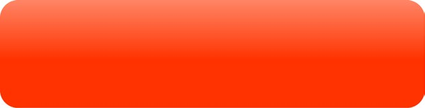

110 studies excluded by title

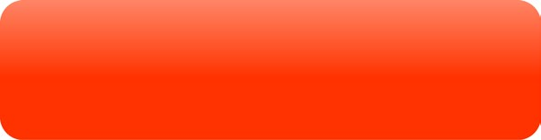

40 studies excluded by

abstract

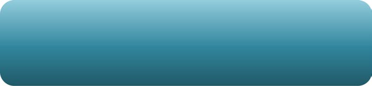

73 records eligible for

abstract screening

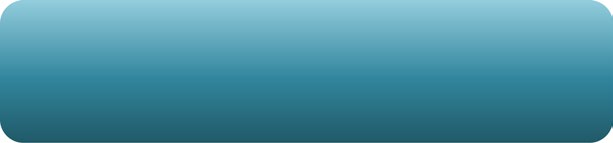

33 records assessed for

inclusion eligibility

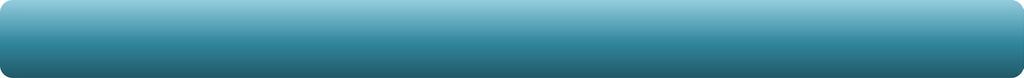

451 records identified via “PubMed” and “Web of Science” database searching

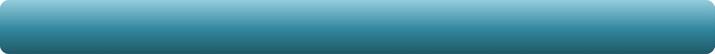

183 records remaining after removal of duplicates, eligible for title screening

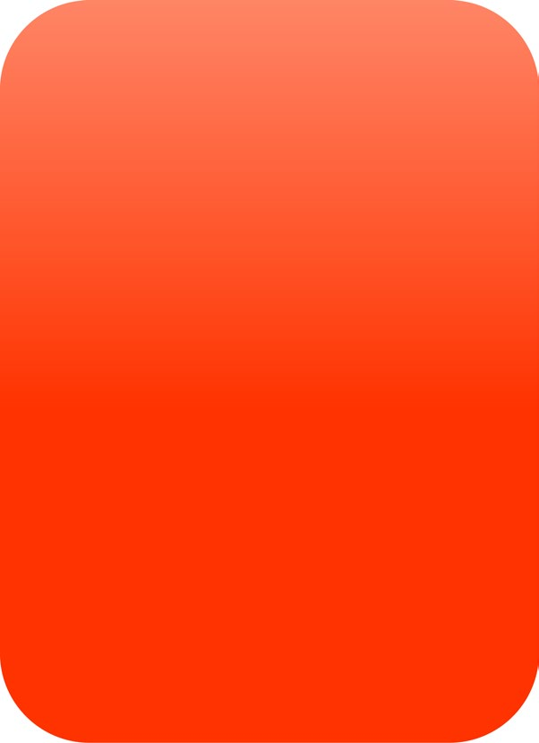

25 of the full-text articles

excluded for the following

reasons: Missing control

group, insufficient

reporting of methodology

and/or results, results not

relevant for synthesis, full

text not available in

English, unconventional

way to prepare the

muscle-in-vein conduits

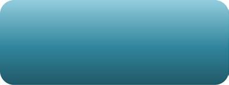

Preclinical

studies

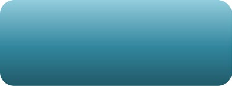

Clinical studies

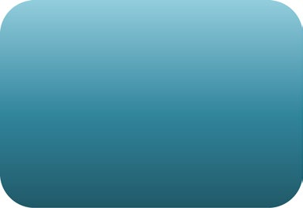

2 studies

included in

quantitative

synthesis

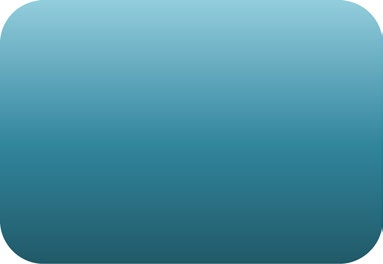

8 studies

included in

quantitative

synthesis

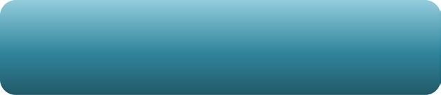

2 additional studies identified

by reference screening

**Figure 1.** Flow diagram of the search and study selection process. The selection process, based on the PRISMA-

guidelines, is depicted in chronological order.

4

Vol:.(1234567890)

**Scientific Reports** | (2021) 11:11691 |

https://doi.org/10.1038/s41598-021-90956-3

www.nature.com/scientificreports/

nerve model and a total of 45 rats. MVC treated animals displayed either significantly worse (p < 0.01) motor

recovery than those treated with ANGs<sup>22</sup> or had to be excluded after 4 weeks of follow-up due to severe limb

autotomy<sup>20</sup>. Ramli et al. assessed functional recovery also by means of the Pinch test. Although the authors did

not report any statistical analysis of this data, the published data sheet indicated no marked differences between

the ANG and MVC group<sup>20</sup>.

*Median nerve model*

In the three studies evaluating MVCs versus ANGs in the rat median nerve model, motor function recovery

was assessed in a total of 108 rodents by means of the grasping test. One study<sup>18</sup> with 16 rats featured the staircase

test<sup>23</sup> as an additional assessment tool. Regarding the grasping test, in one study rats treated with MVCs recovered

significantly (p < 0.05) less grasping strength than rats treated with ANGs at six months postoperatively<sup>21</sup>, while

another study reported no significant differences between the two groups<sup>24</sup>. Stossel et al. did not report absolute

grasping strength in grams but made use of a trinary scoring system to evaluate the rats’ grasping ability. While

they found no significant differences between the two groups at postoperative week (WPO) 4 and WPO12,

significantly (p < 0.05) more animals treated with ANGs had regained the ability to pull the bar of the testing

apparatus with measurable force in comparison to the MVC group at WPO8. In regard to the staircase test, the

same authors reported a significant difference (p < 0.05) in favor of the ANG group at WPO4 while there were

no significant differences detectable at WPO8 and WPO12<sup>18</sup>.

*Electrophysiological evaluations*

Electrophysiological evaluations including nerve conduction velocity and the amplitude of the evoked com-

pound muscle action potential (CMAP) were performed in 3 studies and a total of 87 rats.

*Median nerve model*

One study<sup>18</sup> assessed the CMAP amplitudes of the thenar muscles by means of minimally invasive measure-

ments in 16 rats every four weeks following median nerve resection and repair. At WPO4 and WPO8, respec-

tively, no significant differences were detectable between the ANG and MVC group whereas CMAP amplitudes

were highly significantly (p < 0.01) larger in rats treated with ANGs at WPO12. In addition, CMAP amplitudes

in the ANG groups were highly significantly (p < 0.01) increased at WPO12 compared to WPO8. However, this

difference was not significant in the MVC group.

*Sciatic nerve model*

Two studies<sup>17</sup><sup>,</sup><sup>20</sup> evaluated electrophysiological outcome metrics after sciatic nerve injury and repair in a total

of 71 rats. Stossel et al. found that CMAP amplitudes recorded from the tibialis anterior muscles of MVC-treated

animals were highly significantly (p < 0.001) lower than those of the ANG group at DPO60, DPO90 and DPO120.

While CMAP amplitudes in the ANG group were highly significantly higher at DPO90 (p < 0.001) and DPO120

(p < 0.01) in comparison to DPO60. This difference was not significant in the MVC group<sup>17</sup>. The authors also

calculated the estimated axon loss based on their electrophysiologic recordings and found significant (p < 0.05)

lower numbers of axons in the MVC group compared to the ANG group at DPO60. This difference was highly

significant (p < 0.01) at DPO90 and DPO120, respectively. Additionally, Stossel et al. also performed the same

measurements on the plantaris longus muscle. While they found no significant group differences at DPO60,

animals of the ANG group had significantly (p < 0.05) larger CMAP amplitudes at DPO90. This difference was

highly significant (p < 0.001) at DPO120. While there was no significant recovery of CMAP amplitudes in the

MVC group at DPO120 compared to earlier time points, this recovery was highly significant compared to DPO60

(p < 0.001) and DPO90 (p < 0.01) in the ANG group. In regard to the estimated axonal loss, this was highly sig-

nificantly more pronounced (p < 0.001) in the MVC group compared to the ANG group at DPO90 and DPO120.

While a highly significant (p < 0.001) increment in axon numbers compared to baseline was observable in the

ANG group at DPO90 and DPO120, this did not occur in the MVC group.

Ramli and colleagues did not detect significant differences regarding CMAP amplitude, CMAP onset latency

and nerve conduction velocity between the MVC and ANG group<sup>20</sup>.

*Histological evaluations*

Seven of the eight included preclinical studies (median nerve = 2, sciatic nerve = 5) with a total of 173 rats

featured histological analysis of the reconstructed nerve, including 1) number of axons, 2) diameter of axons, 3)

mean density as well as 4) size of myelinated fibers and 5) thickness of the myelin sheath.

*Median nerve model*

Papalia et al. found no significant differences regarding the total number, fiber diameter or myelin thickness

between the ANG and MVC group at 6 months postoperatively<sup>24</sup>, whereas Stossel’s group reported significantly

(p < 0.05) and highly significantly (p < 0.001) lower numbers of myelinated axons in the MVC group at WPO8

and WPO12, respectively. The same authors observed no significant differences regarding the repaired nerves’

mean cross sectional area, axon diameter, fiber diameter, g-ratio or myelin thickness between groups, but found

a highly significantly (p < 0.001) increased nerve fiber density in the ANG group compared to the MVC group

at WPO12<sup>18</sup>.

*Sciatic nerve model*

Brunelli and colleagues, who bridged 10 mm and 20 mm nerve defects of the sciatic nerve in their study,

found a significantly increased number of axons in the distal nerve stumps of animals treated with MVCs when

compared to the ANG group in both settings<sup>11</sup>.

Geuna et al. assessed the total number, mean size and fiber density of myelinated nerve fibers and found no

significant differences between the two groups<sup>25</sup>.

Another study which evaluated histological parameters at DPO120 found that the total number of fibers was

significantly (p < 0.05) lower in the MVC group compared to the ANG group whereas there were no significant

differences regarding nerve fiber density, axon diameter, fiber diameter, g-ratio and myelin thickness <sup>17</sup>.

Ramli and colleagues assessed the (1) number of nerve fibers, (2) degree of angiogenesis, (3) infiltration of

immune cells, (4) infiltration of muscle cells and (5) development of traumatic neuroma. These authors did not

5

Vol.:(0123456789)

**Scientific Reports** | (2021) 11:11691 |

https://doi.org/10.1038/s41598-021-90956-3

www.nature.com/scientificreports/

report results of any statistical comparison between groups but found a higher number of nerve fibers within the

distal stumps of nerves reconstructed with an ANG. While the degree of angiogenesis, immune cell infiltration

and muscle cell infiltration was equivalent between both groups, abundant neuroma formation was apparent in

nerves repaired with MVCs. No neuroma formation was observable in the ANG group<sup>20</sup>.

Ulkur et al. evaluated the number of myelinated axons and the mean axonal diameter at WPO28, reporting

significantly (p < 0.05) higher numbers in regard to both counts in the ANG group<sup>22</sup>.

*Muscle weight*

Stossel’s group assessed muscle weight of both the tibialis anterior muscle and gastrocnemius muscle at

DPO120 following sciatic nerve repair, which was significantly increased in the ANG group compared to the

MVC group<sup>17</sup>.

*Clinical studies.* Manoli’s group found no statistically significant differences in regard to static or moving two-

point discrimination as well as the Semmes–Weinstein-Monofilament test after digital nerve repair (n = 31) with

either an ANG (n = 14) or a MVC (n = 17)<sup>12</sup>. Ahmad et al. also found no statistically significant differences in

regard to two-point discrimination or muscle power assessed by means of the Medical Research Council scale

following nerve repair (n = 18) with either ANGs (n = 9) or MVCs (n = 9)<sup>16</sup>.

**Meta‑analysis.**

Our meta-analysis revealed marked differences regarding the outcome of nerve repair by

means of ANGs or MVCs between preclinical and clinical studies. Figure 2 depicts the quality of all included

preclinical studies (Fig. 2a) and clinical studies (Fig. 2b) in regard to the risk of bias.

*Preclinical studies.* Functional recovery was not significantly different following autologous nerve grafting or

bridging with MVCs at WPO2 (DM, 95% CI, fixed effect: −0.56 [−3.48 to 2.36]d, I<sup>2</sup> = 0%, 45 animals) (Fig. 3a).

WPO6 onwards, no later time points were included in the meta-analysis.

In regard to the number of axons in the distal nerve stump at WPO12 following bridging of a 10 mm sciatic

nerve defect, use of MVCs resulted in significantly (p < 0.01) higher numbers of axons than reconstruction with

an ANG (DM, 95% CI, fixed effect: 3.15 [2.94 to 3.35], I<sup>2</sup> = 98%, 7 animals) (Fig. 4a). In contrast to these superior

results observed in the MVC group, the size of myelinated fibers was significantly (p < 0.01) higher after nerve

reconstruction by means of an ANG at WPO12 (DM, 95% CI, fixed effect: −1.35 [−1.57 to −1.13], I<sup>2</sup> = 99%, 7

animals) (Fig. 4b).

*Clinical studies.* Recovery of sensory function, evaluated by means of static two-point discrimination, was not

significantly different between patients which received MVCs compared to those treated with ANGs (DM, 95%

CI, fixed effect: 0.52 [−0.32 to 1.35], I<sup>2</sup> = 0%, 49 cases in 46 patients) (Fig. 5). However, there was a slight trend

towards better sensory function in the MVC group.

**Discussion**

Reconstruction of nerve defects in which tension-free neurorrhaphy is impossible requires interposition of an

adequate guiding structure to facilitate nerve regeneration. Use of ANGs demands careful consideration, regard-

ing their limited availability and donor site morbidity. An ideal nerve conduit should be abundantly available

throughout the body, with high biocompatibility and -degradability in addition to optimum biomechanical

properties. The nerve within the conduit should be optimally protected from surrounding scar tissue and inflam-

matory cells, while its regeneration is maximally supported<sup>7</sup><sup>,</sup><sup>26</sup>. MVCs were proposed almost three decades ago

by Brunelli, who suggested that their characteristics match most of the aforementioned requirements for an

ideal nerve conduit<sup>11</sup>.

Our review and meta-analysis revealed marked differences between clinical and preclinical data in regard to

the reported efficacy of MVCs and ANGs for peripheral nerve reconstruction. While the results of the included

preclinical studies were mixed, clinical investigations reported non-inferiority of MVCs to ANGs. Due to strong

heterogeneity in study methodology, only a limited number of studies’ data (n = 6) could be included in our

quantitative synthesis, although 10 studies were eligible for inclusion in our qualitative synthesis.

Preclinical studies reported diverging results with especially recent work pointing towards inferiority of MVCs

compared to ANGs. In this context, some important methodological aspects of the included studies need to be

addressed. Early preclinical studies, which affirmed the high potential of MVCs, featured either a very limited

number of animals, e.g. n = 3<sup>11</sup><sup>,</sup><sup>25</sup> or reported only partial results of the respective histological and functional

assessment<sup>11</sup><sup>,</sup><sup>21</sup>. Studies which were published more recently used a broader array of evaluation methods and

group size was at least n = 8<sup>17</sup><sup>,</sup><sup>18</sup>. Additionally, superiority of MVCs in earlier studies was almost exclusively

related to higher axon numbers in the distal nerve stump and no functional outcome was reported. In contrast,

the majority of studies which assessed functional outcome reported inferior results in the MVC groups. Other

authors have emphasized a discrepancy between axon numbers and the degree of functional recovery follow-

ing experimental peripheral nerve injury and regeneration<sup>27</sup>. Since nerve regeneration consists of (1) axonal

regrowth (2) end-organ reinnervation and (3) functional recovery<sup>28</sup> the overall outcome should not be judged

based on results of only one of these three phases. As comprehensive analyses of functional recovery were pri-

marily published in recent works, there is a growing body of literature indicating inferiority of MVCs to ANGs

in preclinical murine models.

6

Vol:.(1234567890)

**Scientific Reports** | (2021) 11:11691 |

https://doi.org/10.1038/s41598-021-90956-3

www.nature.com/scientificreports/

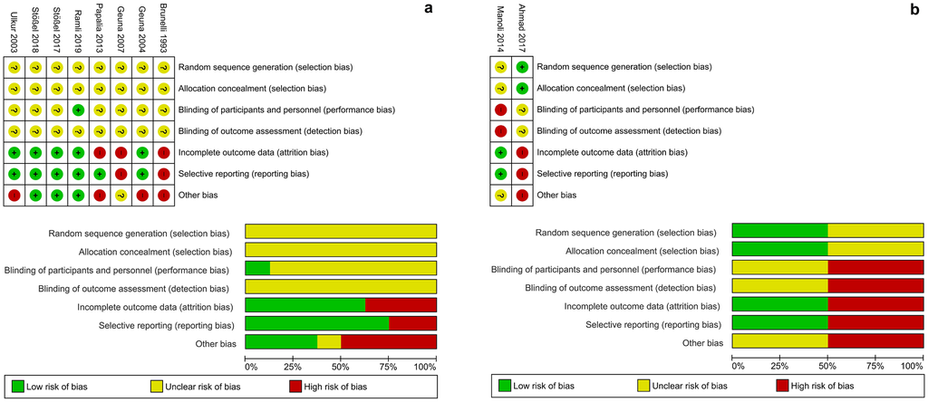

**Figure 2.** Assessed risk of bias of all preclinical (**a**) and clinical (**b**) studies included in the meta-analysis. As

recommended by the PRISMA guidelines, the authors performed an analysis of bias, which could result in over-

or underestimation of the effect of interventions, in all included studies. Depicted are the scored risk of bias for

individual items (upper part) and the percentage of the assessed bias risk (bottom part) across all preclinical (**a**)

and clinical (**b**) studies included in the meta-analysis.

Clinical evaluations of MVCs were performed in a number of studies without an ANG control group<sup>10</sup><sup>,</sup><sup>29</sup><sup>–</sup><sup>31</sup>.

We found only two studies that compared functional outcome to ANGs, both reporting non-inferiority of MVCs

for reconstruction of upper extremity nerve defects.

The underlying reasons for these observed discrepancies between preclinical and clinical results remain to

be elucidated. In our opinion, three major points must be addressed.

First, the way the grafts are prepared and coaptated to the nerve stumps is of crucial relevance regarding the

outcome of nerve reconstruction. Tension-free nerve repair has been emphasized by Millesi as paramount prereq-

uisite for optimal nerve regeneration<sup>32</sup> due to the devastating consequences of tension on intraneural perfusion<sup>33</sup>.

However, there might be differences regarding graft coaptation between preclinical and clinical studies. In the

clinical situation, the patient’s nerve has already been severed, therefore a segmental damage cannot be bridged

with the original nerve. Thus, if an MCV or ANG is placed between the nerve stumps, the surgeon chooses the

respective transplant’s length to guarantee tension-free coaptation. In preclinical studies however, the nerve gap

is created by the experimenter and needs to be of standardized length to guarantee comparability of experimental

results. In consequence, for ANG repair the gap is usually bridged with the original nerve in retrograde fashion.

However, given the tendency of the nerve stumps to retract the nerve gap increases by < 3 mm<sup>34</sup>. Therefore,

tension-free coaptation might be more difficult. In addition, we assume that most experimenters prepare MVCs

of the same length as the ANGs, possibly hampering tension-free repair. This in turn might complicate pulling

the nerve stumps inside the MVC, a crucial aspect of nerve repair by means of this approach<sup>20</sup>. If the nerve is not

pulled inside the MVC regenerating axons might get trapped outside, hindering regeneration<sup>12</sup>.

Second, clinical studies of peripheral nerve repair most commonly feature injuries of digital nerves, which

are relatively small and monofascicular<sup>35</sup>. In opposite, mixed (motor and sensory) multifascicular nerves are

most commonly studied in preclinical studies. Misdirection of axons, which significantly impairs recovery of

target organ function<sup>36</sup>, occurs more likely when a gap of a mixed nerve is bridged with an MVC, which lacks the

fascicular pattern of the original nerve. This is supported by a study reporting non-inferiority of MVCs compared

to primary neurorrhaphy in rats with distal facial nerve injury. Since the nerve is mostly comprised of muscular

fibers at this level, axonal misdirection might be less devastating for functional recovery<sup>37</sup>.

Third, the process of neuroregeneration, despite striking similarities, is markedly different in certain aspects

between rodents and humans<sup>38</sup><sup>,</sup><sup>39</sup>. As prerequisite for successful nerve regeneration, cellular debris and other

potential obstacles for regrowing axons must be removed following Wallerian degeneration<sup>40</sup><sup>,</sup><sup>41</sup>. Next, a fibrin

length of axonal regeneration without interposition of a guidance structure, e.g. the “critical size defect”, which

is ~ 1.5 cm in rats and ~ 4 cm in humans<sup>38</sup>. It was established that longitudinally oriented fibers, e.g. collagen or

muscle, can support axonal regrowth and functional recovery<sup>11</sup><sup>,</sup><sup>43</sup><sup>,</sup><sup>44</sup>. However, nerve regeneration is hindered

if these guidance structures are degraded before regenerating axons reach them. On the other hand, the fibers

must be fully degraded before nerve regeneration is finished, otherwise complete recovery will be impeded<sup>45</sup>.

The muscle fibers inside an MVC<sup>46</sup> are degraded by proteases while simultaneous axon regrowth through the

fibrin cable occurs. It was shown that an MVC collapses as soon as all muscle fibers within have been degraded,

which decidedly hinders axonal regeneration<sup>17</sup>. As shown for mice, rodents possess about 1.4 × the number of

7

Vol.:(0123456789)

**Scientific Reports** | (2021) 11:11691 |

https://doi.org/10.1038/s41598-021-90956-3

www.nature.com/scientificreports/

proteases and have a markedly increased proteome turnover in comparison to humans<sup>47</sup>. This is thought to be

related to their shorter lifespan with their body optimized to quickly regain optimal integrity and function rather

than maintaining the body over a long time<sup>48</sup>. We therefore hypothesize, that muscle fibers inside MVCs are

degraded markedly faster in rodents than in humans, contributing to the inferior results of MVC nerve repair in

murine models. As human proteome turnover is slower, muscle fibers inside the MVC persist longer, allowing

more time for axons to transverse the MVC before it collapses.

These profound differences impair clinical translation of results in rodent studies of peripheral nerve repair,

especially in regard to critical size defects. However, critical size nerve defects represent a common clinical

problem with a high need for adequate treatment options<sup>38</sup><sup>,</sup><sup>39</sup>. Out of the eight preclinical studies included in this

work, three featured a critical size nerve defect. Two of these studies were published within the last 3 years and

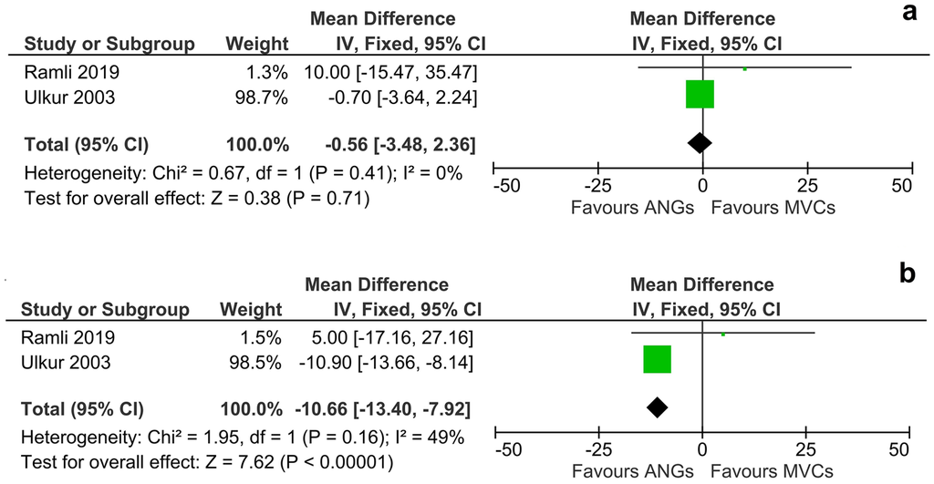

**Figure 3.** Meta-analysis of walking track performances (preclinical). Walking track performance at either

2 weeks (**a**) or 4 weeks (**b**) after sciatic nerve surgery was compared between rats who underwent nerve

reconstruction either by means of an ANG or MVC. While the overall effect of the respective reconstruction

method was not significant at WPO2, the meta-analysis revealed a significant effect (p < 0.01) in favor of

ANGs at WPO4. While functional recovery was assessed by walking track analysis until WPO12 and WPO28,

respectively, Ramli et al. excluded all animal of the MVC group starting from WPO6 due to severe autotomy of

the affected limb. Therefore no meta-analysis of walking track analysis was performed at time points later than

WPO4. Note that while no heterogeneity (I<sup>2</sup> = 0%) was detectable at WPO2, a moderate amount of heterogeneity

(I<sup>2</sup> = 49%) was observable at WPO4.

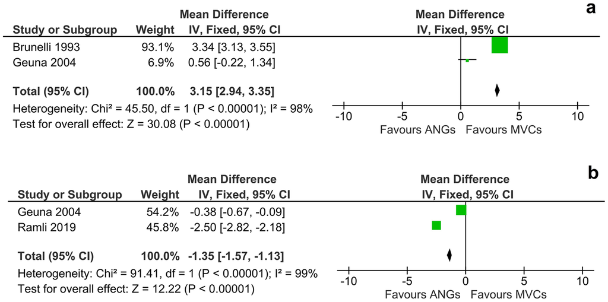

**Figure 4.** Meta-analysis of the number of axons in the distal nerve stump (**a**) and the size of the myelinated

fibers (**b**) within the grafted ANG or MVC at twelve weeks following sciatic nerve reconstruction (preclinical).

Analysis of axon numbers (**a**) at WPO12 revealed a statistically significant (p < 0.01) effect of nerve

reconstruction by means of MVCs compared to ANGs. There was high heterogeneity (I<sup>2</sup> = 98%) among the

evaluated studies. Note that the scale of the Forrest-plot was adapted to 1000 axons/mm<sup>2</sup> as the software allows

a maximum scale of 1000. Analysis of the size of myelinated fibers (**b**) at WPO12 showed a significant effect

(p < 0.01) in favor of nerve repair by means of ANGs. We observed a high heterogeneity of I<sup>2</sup> = 99%.

8

Vol:.(1234567890)

**Scientific Reports** | (2021) 11:11691 |

https://doi.org/10.1038/s41598-021-90956-3

www.nature.com/scientificreports/

included at least two assessments for functional recovery each. Notably, all three studies reported inferiority of

MVCs to ANGs for bridging long nerve defects in rodents. Clinical results of MVCs vs ANGs after reconstruc-

tion of peripheral nerve defects > 3 cm were only reported by Manoli et al.<sup>12</sup>. The authors reconstructed four

4–6 cm gaps, two each with an ANG or an MVC. Interestingly, they reported a good and a poor result each for

both methods. Due to the limited numbers of patients, no statistical analysis could be performed between the

group of patients with 4–6 cm defects and the group with smaller nerve gaps. Since long defects of 6 cm and more

are often associated with markedly worse or even no functional recovery<sup>34</sup>, it could be assumed that the overall

results, e.g. non-inferiority of MVCs to ANGs, were at least partially influenced by the length of the nerve gaps

in this study. Other authors published good results after repair of 4–6 cm long nerve gaps with MVCs, but their

study lacked an ANG group<sup>10</sup>. Therefore, no concise conclusion is possible in regard to the feasibility of MVCs

vs ANGs for reconstruction of long nerve defects in human patients <sup>49</sup>.

Although promising results for MVCs were obtained in a small number of clinical studies, there is evident

need for larger, clinical trials to gather more data. Based on the results of this work we see a strong need to

investigate MVCs in the setting of a critical size nerve defect in a non-rodent model. The disadvantages of rodent

models, although cost-efficient and commonly used, have been pointed out by us. Large mammalians models

such as sheep or pigs come with considerably higher costs as a disadvantage <sup>50</sup>. However, the results of these

animal models are more easily transferable to human patients <sup>51</sup>. Therefore, we advise evaluation of MVCs in

large animal models before further clinical studies involving mixed motor nerves or nerve gaps of critical size

should be intended.

**Conclusion**

Our results underpin that preclinical studies in rodents are not able to adequately prognose the feasibility of

MVCs for reconstruction of critical-size defects in humans. This can be explained by differences regarding the

experimental settings, and most important, profound inter-species differences in neurobiology. Additionally,

data from clinical trials, in particular involving defects of mixed nerves, are still very sparse. Although large

prospective human studies to answer these questions will be inevitable, we strongly advise for large animal stud-

ies beforehand. Our work emphasizes two main problems of peripheral nerve research: limited translatability

of results from rodents to humans and profound differences regarding study methodology. While MVCs tackle

several main problems of peripheral nerve repair by means of an abundantly available, autologous material with

high biocompatibility, their promising features have not yet been explored in enough detail to support their

unfettered use for nerve repair in human patients.

**Methods**

According to the PRISMA statement<sup>52</sup> and in adherence with the recommendations found in the literature<sup>53</sup>, a

systematic review and meta-analysis was conducted to investigate the use of MVCs as alternative to ANGs for

reconstruction of segmental peripheral nerve defects. Both preclinical and clinical studies were featured in the

data synthesis.

**Search strategy, eligibility, and inclusion criteria.**

In accordance with the PRISMA guidelines and

exemplary published work<sup>53</sup>, a systematic search strategy (Supplementary Table 1) was designed in August 2020

for the database PubMed and Web of Science core collection. The latest literature research was performed on

December 1st, 2020. All identified studies in this research were then screened for general eligibility and inclusion

using a predefined list of inclusion criteria both for the preclinical as well as the clinical studies (Table 1). All

experimental animal studies in rats which compared MVCs against the gold standard of ANGs were hypotheti-

cally eligible for inclusion into the analysis of preclinical data. Regarding the analysis of clinical data, all clinical

studies investigating the use of MVCs versus ANGs to reconstruct segmental nerve defects in humans were

theoretically deemed eligible. Studies which were identified through literature research but did not meet the

inclusion criteria were excluded from the analysis (Supplementary Table 2 + Supplementary Table 3).

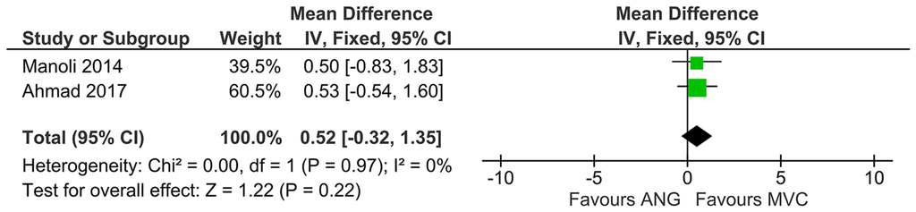

**Figure 5.** Meta-analysis of static two-point discrimination (clinical). There was no significant effect (p = 0.22) of

the reconstructive method on static two-point discrimination detectable. No heterogeneity among the analyzed

studies was detectable (I<sup>2</sup> = 0%). Note that while the estimated effects of interventions for both studies were

only slightly different (0.53 vs 0.50), Ahmad’s study was given more weight and therefore more influence on the

average effect of interventions due to the narrower confidence interval in comparison to Manoli’s work (2.14 vs.

2.66).

9

Vol.:(0123456789)

**Scientific Reports** | (2021) 11:11691 |

https://doi.org/10.1038/s41598-021-90956-3

www.nature.com/scientificreports/

**Selection of studies and extraction of data.**

Following the initial literature research, the identified

studies’ abstracts and titles were screened to identify all studies potentially eligible for inclusion. All studies

meeting these criteria were obtained in full text. There studies were then assessed thoroughly for their eligibility

for inclusion and their reference lists were used to search for additional relevant publications. In the next step,

all relevant data was extracted (Tables 2, 3) and prepared for analysis. Since the degree of functional recovery is

the most important criterion to determine the feasibility and effects of a reconstructive technique in peripheral

nerve repair<sup>54</sup>, we chose recovery of voluntary motor function as the primary outcome parameter for the pre-

clinical studies.

Given the predominance of the rat sciatic nerve model in preclinical peripheral nerve research<sup>55</sup>, calculation

of the Sciatic Functional Index (SFI) or Peroneal Functional Index (PFI) by means of walking track analysis are

well-established tools to determine the degree of functional recovery in this context<sup>56</sup>. Established by de Medi-

naceli et al. in 1982, these methods include dipping the rat’s hind paws in ink to be subsequently recorded and

measured. While values around zero indicate normal function, an SFI of around -100 equals complete loss of

function<sup>57</sup>. Sensory recovery can be evaluated by means of the “Pinch Test”, in which toothed forceps are used

to nip the toes of the respective paw.

Besides the rat sciatic nerve model, the median nerve model is another frequently used model in preclinical

research<sup>58</sup>. Voluntary motor function in this model is most commonly assessed by means of the grasping test.

**Table 2.** Extracted details of the included preclinical studies.

**Study**

**Nerve**

**Defect size**

**Surgical methods**

**Included animals**

**Observation period**

**Outcomes**

Brunelli <sup>11</sup>

Sciatic

(A) 10 mm

(B) 20 mm

(1) ANG

(2) Muscle alone

(3) Empty vein graft

(4) MVC

n = 24

12 weeks

Functional examination (not further speci-

fied), number of axons

Geuna <sup>25</sup>

Sciatic

10 mm

(1) Control

(2) MVC

(3) ANG

n = 12

12 weeks

Total number, mean density and size of

myelinated fibers

Geuna <sup>21</sup>

Median

10 mm

(1) End-to-side repair using the ulnar nerve

(2) ANG

(3) MVC

(4) Y-shaped MVC on median nerve

(5) Y-shaped MVC on ulnar nerve

n = 72

10 months

Functional examination (grasping test),

histological analysis

Papalia <sup>24</sup>

10 mm

(1) Epigastric vein filled with adipose tissue

(2) ANG

(3) MVC

n = 20

6 months

Functional examination (grasping test), total

number, diameter of myelinated fibers and

myelin thickness after 6 months

Ramli <sup>20</sup>

Sciatic

15 mm

(1) ANG

(2) No treatment

(3) MVC with neural transdifferentiated

MSCs

(4) unseeded MVC

(5) polyglycolic acid nerve conduit

n = 15

12 weeks

Sensory function (pinch test) and motor

function assessment (walking tracks), nerve

conduction velocity, fiber diameter, axon

diameter and myelin thickness

Stössel <sup>18</sup>

Median

7 mm

(1) MVC

(2) ANG

n = 16

8 weeks and 12 weeks

Functional examination (grasping test, stair-

case test), nerve conduction velocity every

4 weeks, diameter of myelinated fibers and

axons, myelin thickness

Stössel <sup>17</sup>

Sciatic

15 mm

(A) immediate repair B) repair postponed

for 45 days

(1) regular chitosan

(2) novel chitosan

(3) ANG

(4) MVC

n = 56

120 days (acute repair),

150 days (delayed)

Transcutaneous electrodiagnostic, muscle

weight ratios, total nerve fiber number, nerve

fiber density, diameter of axons and fibers

and myelin thickness

Ülkür <sup>22</sup>

Sciatic

20 mm

(1) ANT

(2) vein only

(3) MVC

n = 30

28 weeks

Functional examination (walking track) in

week 2, 4, 8, 12, 20, and 28, number of myeli-

nated axons and mean axonal diameter

**Table 3.** Extracted details of the included clinical studies. *: Note that the number of cases was higher than

the number of patients because three patients in the MVC group each underwent reconstruction of two digital

nerve defects with MVCs.

**Study**

**Nerves**

**Defect size**

**Surgical methods**

**Included patients**

**Age range**

**Observation period**

**Outcomes**

Ahmad <sup>16</sup>

Median Ulnar

< 30 mm

(1) ANG using the sural nerve

(2) MVC

n = 18

(1) n = 9

(2) n = 9

1) 27.22 ± 5.35

2) 26.80 ± 5.50

not reported

Static two-point discrimination,

muscle power

Manoli <sup>12</sup>

Digital

10 – 60 mm

(1) ANG using the medial ante-

brachial cutaneous nerve

(2) MVC

n = 28*

Cases:

(1) n = 14

(2) n = 17

11 – 72 years

12 – 58 months

Semmes–Weinstein monofila-

ments, static + moving two-point

discrimination

10

Vol:.(1234567890)

**Scientific Reports** | (2021) 11:11691 |

https://doi.org/10.1038/s41598-021-90956-3

www.nature.com/scientificreports/

While being held at its tail, the rat grasps a bar connected to a scale to measure and record the maximum force

exercisable by the finger flexor muscles. As these are predominantly innervated by the median nerve in rats, this

method allows to determine the degree of functional recovery after median nerve reconstruction. The staircase

test is an alternative method to assess motor function following median nerve injury and reconstruction. It

evaluates the fine motor skills of the forelimb while the examined rat retrieves spheroid-shaped pellets of food

from a staircase apparatus with restricted latitude<sup>18</sup>. As secondary outcome, electrophysiological parameters

such as the nerve conduction velocity (NCV) or the compound muscle action potential (CMAP) of the respec-

tive target muscles were evaluated. Muscle weights of target muscles were chosen as complementary outcome

metrics. Additionally, histological and histomorphometric parameters, e. g. the diameter of myelinated axons,

the myelin sheath thickness, g-ratio and the density or number of myelinated nerve fibers distal to the lesion site

or inside the MVC and ANG were assessed. Regarding the clinical studies included in our synthesis, recovery

of sensory function as assessed by static two-point discrimination was chosen as primary outcome parameter.

Additional outcome metrics were moving two-point discrimination, the Semmes–Weinstein-monofilament test

which is used to assess cutaneus sensory thresholds by applying nylon filaments of different bendability to the

respective skin area, and the Medical Research Council scale<sup>59</sup> for muscle strength. The methodological quality of

all included studies was assessed and the risk of bias was judged in accordance with the recommendations of the

Cochrane Handbook for Systematic Reviews of Interventions<sup>60</sup> for the following aspects: random sequence gen-

eration and allocation concealment (selection bias), blinding of participants and personnel (performance bias),

blinding of outcome assessment (detection bias), incomplete outcome data (attrition bias), selective reporting

(reporting bias) and other bias, e.g. suspected insufficient statistical power or methods or use of non-standardized

or strongly modified experimental methods.

**Statistical analysis, qualitative and quantitative synthesis of data.**

We performed the meta-anal-

ysis and created the respective figures using Cochrane statistical software Review Manager 5.3<sup>61</sup> (The Cochrane

Collaboration, Copenhagen, the Nordic Cochrane Centre). Preclinical studies were clustered into two groups,

either featuring the sciatic nerve or median nerve model. Further statistical subgroup analysis was based on

this sorting. However due to a strong heterogeneity regarding the assessed outcomes, length of the observation

period and surgical methodology, a meta-analysis could only be performed on the sciatic nerve model group.

We used the inverse variance (IV) method in a fixed effect analysis-model and expressed the results as difference

in means (DM) for continuous outcomes with 95% confidence interval (CI). Since the Review Manager requires

the standard deviation for each outcome, but some studies reported the standard error of the mean (SEM)

instead, the Standard Deviation was calculated by multiplying the square root of the sample sizes with the SEM.

The weight of the estimated intervention effect of each individual study was then determined based on the width

of the confidence intervals of the respective study. In conclusion, studies with narrower confidence intervals had

a higher impact on the overall average effect of interventions for the respective reconstructive approach (MVC

or ANG respectively)<sup>62</sup>. Heterogeneity among studies was assessed by means of the Chi<sup>2</sup> and I<sup>2</sup> test<sup>63</sup>.

**Data availability**

The original contributions presented in the study are included in the article, further inquiries can be directed

to the corresponding author.

Received: 12 February 2021; Accepted: 17 May 2021

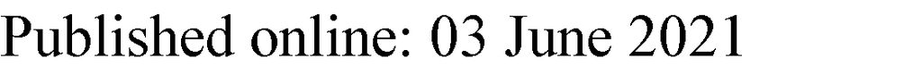

**References**

1. Foster, C. H. *et al.* Trends and cost-analysis of lower extremity nerve injury using the national inpatient sample. *Neurosurgery* **85**,

250–256 (2019).

2. Karsy, M. *et al.* Trends and cost analysis of upper extremity nerve injury using the national (nationwide) inpatient sample. *World*

*Neurosurg* **123**, e488–e500 (2019).

3. Siqueira, M.G. & Martins, R.S. Conventional strategies of nerve repair In *Modern Concepts of Peripheral Nerve Repair* (eds. Haastert-

Talini, K., Assmus, H. & Antoniadis, G.) 41-51 (Springer International Publishing, Cham, 2017).

4. Houschyar, K. S. *et al.* The role of current techniques and concepts in peripheral nerve repair. *Plast. Surg. Int.* **2016**, 4175293 (2016).

5. Pan, D., Mackinnon, S.E. & Wood, M.D. Advances in the repair of segmental nerve injuries and trends in reconstruction. *Muscle*

*Nerve* **61**, 726–739 (2020).

6. Siemionow, M. & Brzezicki, G. Chpter 8: Current techniques and concepts in peripheral nerve repair. *Int. Rev. Neurobiol.* **87**,

141–172 (2009).

7. Carvalho, C. R., Oliveira, J. M. & Reis, R. L. Modern trends for peripheral nerve repair and regeneration: Beyond the hollow nerve

guidance conduit. *Front. Bioeng. Biotechnol.* **7**, 337 (2019).

8. Wrede, L. Uberbrueckung eines nervendefektes mittels seidennaht und lebenden venenstueckes (Bridging nerve defects by means

of stitches and vein segments). *Deutsches Med Wochenschrift* **35**, 1125 (1909).

9. Chiu, D. T., Janecka, I., Krizek, T. J., Wolff, M. & Lovelace, R. E. Autogenous vein graft as a conduit for nerve regeneration. *Surgery*

**91**, 226–233 (1982).

10. Battiston, B., Tos, P., Cushway, T. R. & Geuna, S. Nerve repair by means of vein filled with muscle grafts I. Clinical results. *Micro-*

*surgery* **20**, 32–36 (2000).

11. Brunelli, G. A., Battiston, B., Vigasio, A., Brunelli, G. & Marocolo, D. Bridging nerve defects with combined skeletal muscle and

vein conduits. *Microsurgery* **14**, 247–251 (1993).

12. Manoli, T., Schulz, L., Stahl, S., Jaminet, P. & Schaller, H. E. Evaluation of sensory recovery after reconstruction of digital nerves

of the hand using muscle-in-vein conduits in comparison to nerve suture or nerve autografting. *Microsurgery* **34**, 608–615 (2014).

13. Brunelli, G. A., Vigasio, A. & Brunelli, G. R. Different conduits in peripheral nerve surgery. *Microsurgery* **15**, 176–178 (1994).

14. Di Benedetto, G. *et al.* Nerve regeneration through a combined autologous conduit (vein plus acellular muscle grafts). *Biomaterials*

**19**, 173–181 (1998).

11

Vol.:(0123456789)

**Scientific Reports** | (2021) 11:11691 |

https://doi.org/10.1038/s41598-021-90956-3

www.nature.com/scientificreports/

15. Battiston, B., Tos, P., Geuna, S., Giacobini-Robecchi, M. G. & Guglielmone, R. Nerve repair by means of vein filled with muscle

grafts II. Morphological analysis of regeneration. *Microsurgery* **20**, 37–41 (2000).

16. Ahmad, I., Mir, M. A. & Khan, A. H. An evaluation of different bridging techniques for short nerve gaps. *Ann. Plast. Surg.* **79**,

482–485 (2017).

17. Stossel, M. *et al.* Comparative evaluation of chitosan nerve guides with regular or increased bendability for acute and delayed

peripheral nerve repair: A comprehensive comparison with autologous nerve grafts and muscle-in-vein grafts. *Anat. Rec. (Hoboken)*

**301**, 1697–1713 (2018).

18. Stossel, M., Rehra, L. & Haastert-Talini, K. Reflex-based grasping, skilled forelimb reaching, and electrodiagnostic evaluation for

comprehensive analysis of functional recovery-The 7-mm rat median nerve gap repair model revisited. *Brain Behav* **7**, e00813

(2017).

19. Paprottka, F. J. *et al.* Sensory recovery outcome after digital nerve repair in relation to different reconstructive techniques: meta-

analysis and systematic review. *Plast Surg Int* **2013**, 704589 (2013).

20. Ramli, K. *et al.* Efficacy of human cell-seeded muscle-stuffed vein conduit in rat sciatic nerve repair. *Tissue Eng. Part A* **25**,

1438–1455 (2019).

21. Geuna, S. *et al.* Functional, morphological and biomolecular assessment of posttraumatic neuro-muscular recovery in the rat

forelimb model. *Acta Neurochir. Suppl.* **100**, 173–177 (2007).

22. Ulkur, E., Yuksel, F., Acikel, C., Okar, I. & Celikoz, B. Comparison of functional results of nerve graft, vein graft, and vein filled

with muscle graft in end-to-side neurorrhaphy. *Microsurgery* **23**, 40–48 (2003).

23. Skilled forelimb reaching in Wistar rats: evaluation by means of Montoya staircase test. Pagnussat Ade, S., Michaelsen, S.M.,

Achaval, M. & Netto, C.A. Skilled forelimb reaching in Wistar rats. *J. Neurosci. Methods* **177**, 115–121 (2009).

24. Papalia, I. *et al.* Repairing nerve gaps by vein conduits filled with lipoaspirate-derived entire adipose tissue hinders nerve regenera-

tion. *Ann. Anat.* **195**, 225–230 (2013).

25. Geuna, S., Tos, P., Battiston, B. & Giacobini-Robecchi, M. G. Bridging peripheral nerve defects with muscle-vein combined guides.

*Neurol. Res.* **26**, 139–144 (2004).

26. Houshyar, S., Bhattacharyya, A. & Shanks, R. Peripheral nerve conduit: Materials and structures. *ACS Chem. Neurosci.* **10**, 3349–

3365 (2019).

27. van Neerven, S. G. *et al.* Retrograde tracing and toe spreading after experimental autologous nerve transplantation and crush

injury of the sciatic nerve: a descriptive methodological study. *J. Brachial. Plex. Peripher. Nerve Inj.* **7**, 5 (2012).

28. Navarro, X. Functional evaluation of peripheral nerve regeneration and target reinnervation in animal models: a critical overview.

*Eur. J. Neurosci.* **43**, 271–286 (2016).

29. Battiston, B., Tos, P., Conforti, L. G. & Geuna, S. Alternative techniques for peripheral nerve repair: conduits and end-to-side

neurorrhaphy. *Acta Neurochir. Suppl.* **100**, 43–50 (2007).

30. Marcoccio, I. & Vigasio, A. Muscle-in-vein nerve guide for secondary reconstruction in digital nerve lesions. *J. Hand Surg. Am.*

**35**, 1418–1426 (2010).

31. Schiefer, J. L. *et al.* Comparison of short- with long-term regeneration results after digital nerve reconstruction with muscle-in-vein

conduits. *Neural Regen. Res.* **10**, 1674–1677 (2015).

32. Millesi, H. On the problem of overbridging defects of the peripheral nerves. *Wien Med Wochenschr* **118**, 182–187 (1968).

33. Miyamoto, Y. Experimental studies on repair for peripheral nerves–relationship between circulatory disturbance at nerve stumps

caused by tension at suture line and axon regeneration. *Hiroshima J. Med. Sci.* **28**, 87–93 (1979).

34. Kuffler, D.P. & Foy, C. Restoration of neurological function following peripheral nerve trauma. *Int J Mol Sci* **21**, 1808 (2020).

35. Herman, Z. J. & Ilyas, A. M. Sensory outcomes in digital nerve repair techniques: An updated meta-analysis and systematic review.

*Hand (N Y)* **15**, 157–164 (2020).

36. de Ruiter, G. C., Spinner, R. J., Verhaagen, J. & Malessy, M. J. Misdirection and guidance of regenerating axons after experimental

nerve injury and repair. *J. Neurosurg.* **120**, 493–501 (2014).

37. Manthou, M.E., et al. Facial nerve repair by muscle-vein conduit in rats: functional recovery and muscle reinnervation. *Tissue Eng*

*Part A* **27**, 351–631 (2021).

38. Kaplan, H. M., Mishra, P. & Kohn, J. The overwhelming use of rat models in nerve regeneration research may compromise designs

of nerve guidance conduits for humans. *J. Mater. Sci. Mater. Med.* **26**, 226 (2015).

39. Kornfeld, T., Vogt, P. M. & Radtke, C. Nerve grafting for peripheral nerve injuries with extended defect sizes. *Wien Med Wochenschr*

**169**, 240–251 (2019).

40. Brook, G.A., Hodde, D. & Kretschmer, T. Grundlegendes zu Degeneration und Regeneration von Nerven. In *Nervenchirurgie:*

*Trauma, Tumor, Kompression* (eds. Kretschmer, T., Antoniadis, G. & Assmus, H.) 1–10 (Springer Berlin Heidelberg, Berlin, Hei-

delberg, 2014).

41. Haastert-Talini, K. Peripheral Nerve Tissue Engineering: An Outlook on Experimental Concepts. In *Modern Concepts of Peripheral*

*Nerve Repair* (eds. Haastert-Talini, K., Assmus, H. & Antoniadis, G.) 127–138 (Springer International Publishing, Cham, 2017).

42. Heinzel, J.C., Gloeckel, M., Gruber, A., Heher, P. & Hercher, D. Fibrin in Nerve Tissue Engineering. In *Peripheral Nerve Tissue*

*Engineering and Regeneration* (eds. Phillips, J., Hercher, D. & Hausner, T.) 1–43 (Springer International Publishing, Cham, 2020).

43. Meek, M. F., Varejao, A. S. & Geuna, S. Use of skeletal muscle tissue in peripheral nerve repair: Review of the literature. *Tissue Eng.*

**10**, 1027–1036 (2004).

44. Bozkurt, A. *et al.* Efficient bridging of 20 mm rat sciatic nerve lesions with a longitudinally micro-structured collagen scaffold.

*Biomaterials* **75**, 112–122 (2016).

45. Rizvi, A. H., Pins, G. D. & Silver, F. H. Peripheral nerve regeneration in the presence of collagen fibers: Effect of removal of the

distal nerve stump. *Clin. Mater.* **16**, 73–80 (1994).

46. Janney, N. W. Concerning the protein content of meat. *Proc. Soc. Exp. Biol. Med.* **13**, 83–84 (1916).

47. Puente, X. S., Sanchez, L. M., Overall, C. M. & Lopez-Otin, C. Human and mouse proteases: A comparative genomic approach.

*Nat. Rev. Genet.* **4**, 544–558 (2003).

48. Swovick, K. *et al.* Cross-species comparison of proteome turnover kinetics. *Mol. Cell Proteom.* **17**, 580–591 (2018).

49. Lohmeyer, J. Venen-Muskel-Interponate bei monofaszikulären Nervendefekten. . *Handchirurgie Scan* **04**, 13–14 (2015).

50. Bergmeister, K. D. *et al.* Simulating surgical skills in animals: Systematic review, costs & acceptance analyses. *Front. Vet. Sci.* **7**,

570852 (2020).

51. Angius, D. *et al.* A systematic review of animal models used to study nerve regeneration in tissue-engineered scaffolds. *Biomaterials*

**33**, 8034–8039 (2012).

52. Page, M. J. *et al.* The PRISMA 2020 statement: An updated guideline for reporting systematic reviews. *Int. J. Surg.* **88**, 105906

(2021).

53. Daeschler, S. C. *et al.* Ultrasound and shock-wave stimulation to promote axonal regeneration following nerve surgery: A systematic

review and meta-analysis of preclinical studies. *Sci. Rep.* **8**, 3168 (2018).

54. Heinzel, J. *et al.* Use of the CatWalk gait analysis system to assess functional recovery in rodent models of peripheral nerve injury:

A systematic review. *J. Neurosci. Methods* **345**, 108889 (2020).

55. Vela, F. J. *et al.* Animal models used to study direct peripheral nerve repair: a systematic review. *Neural Regen. Res.* **15**, 491–502

(2020).

12

Vol:.(1234567890)

**Scientific Reports** | (2021) 11:11691 |

https://doi.org/10.1038/s41598-021-90956-3

www.nature.com/scientificreports/

56. Hare, G. M. *et al.* Walking track analysis: A long-term assessment of peripheral nerve recovery. *Plast. Reconstr. Surg.* **89**, 251–258

(1992).

57. de Medinaceli, L., Freed, W. J. & Wyatt, R. J. An index of the functional condition of rat sciatic nerve based on measurements made

from walking tracks. *Exp. Neurol.* **77**, 634–643 (1982).

58. Ronchi, G., et al. The median nerve injury model in pre-clinical research – a critical review on benefits and limitations. *Front. Cell.*

*Neurosci.* **13**, 288 (2019).

59. James, M. A. Use of the Medical Research Council muscle strength grading system in the upper extremity. *J. Hand Surg. Am.* **32**,

154–156 (2007).

60. Higgins, J.P., Savović, J., Page, M.J., Elbers, R.G. & Sterne, J.A. Assessing risk of bias in a randomized trial. In *Cochrane Handbook*

*for Systematic Reviews of Interventions* (eds. Higgins, J.P. et al.) 205–228 (The Cochrane Collaboration, 2019).

61. Review Manager (RevMan) [Computer program]. Version 5.3. (The Cochrane Collaboration, Copenhagen: The Nordic Cochrane

Centre, 2014).

62. Deeks, J.J., Higgins, J.P. & Altman, D.G. Analysing data and undertaking meta-analyses. In *Cochrane Handbook for Systematic*

*Reviews of Interventions* (eds. Higgins, J.P. et al.) 241–284 (The Cochrane Collaboration, 2019).

63. Higgins, J. P., Thompson, S. G., Deeks, J. J. & Altman, D. G. Measuring inconsistency in meta-analyses. *BMJ* **327**, 557–560 (2003).

**Acknowledgements**

We acknowledge support by Open Access Publishing Fund of University of Tübingen.

**Author contributions**

J.H., M.N., L.K. and C.P. extracted and analysed the data; J. H. and C. P. prepared the figures and tables and

organized the manuscript. J.H. wrote the manuscript. J.K. and D.H. conceptualized the work. L.K., A.D., D.H.

and J.K critically read and revised the manuscript. All authors read and approved the submitted final version.

**Funding**

Open Access funding enabled and organized by Projekt DEAL.

**Competing interests**

The authors declare no competing interests.

**Additional information**

**Supplementary Information** The online version contains supplementary material available at https:// doi. org/

10. 1038/ s41598- 021- 90956-3.

**Correspondence** and requests for materials should be addressed to J.C.H.

**Reprints and permissions information** is available at www.nature.com/reprints.

**Publisher’s note** Springer Nature remains neutral with regard to jurisdictional claims in published maps and

institutional affiliations.

**Open Access** This article is licensed under a Creative Commons Attribution 4.0 International

License, which permits use, sharing, adaptation, distribution and reproduction in any medium or

format, as long as you give appropriate credit to the original author(s) and the source, provide a link to the

Creative Commons licence, and indicate if changes were made. The images or other third party material in this

article are included in the article’s Creative Commons licence, unless indicated otherwise in a credit line to the

material. If material is not included in the article’s Creative Commons licence and your intended use is not

permitted by statutory regulation or exceeds the permitted use, you will need to obtain permission directly from

the copyright holder. To view a copy of this licence, visit http:// creat iveco mmons. org/ licen ses/ by/4. 0/.

© The Author(s) 2021